# Network data and graphs

Day 20

## Statistical Analysis of networks

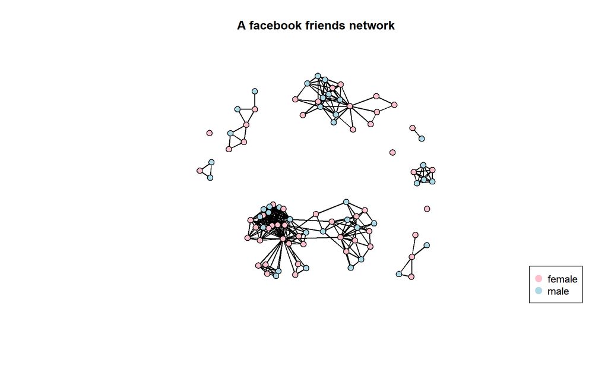

## Networks

- A network consists of vertices (nodes) and edges (ties)
- Vertices: these are usually the “who” or cases in the network
  - people, countries, banks
- Edges: these connect vertices by some defined relationship
  - people: friendship
  - countries: trade, migration
  - banks: lending, borrowing

## Networks

- Edges may or may not be directional
  - undirected: \(A \leftrightarrow B\)
    - Ann is friends with Bob and Bob is friends with Ann
  - directed: \(A \rightarrow B\)
    - Ann thinks she is friends with Bob but Bob doesn’t consider Ann a friend

## Network data

- Data collected on networks can describe the vertex or edge
- Vertex data
  - variables measured on the vertices like sex, age, country GDP, etc
  - represented in an \(n \times p\) data frame (\(p\)=number of variables)
- Edge data
  - variables that describe the ties between two vertices
  - undirected: \(e_{AB}\) measures the amount of time that Ann and Bob spend together in a week
  - directed: value can depend on the direction
    - \(e_{AB}\) measures the number of migrants from Algeria to Brazil
    - \(e_{BA}\) measures the number of migrants from Brazil to Algeria

## Network data

- Relationship data: how are the nodes connected to each other?
- Two ways to store this information:
  - Adjacency matrix: \(n \times n\) matrix with
    - \((i,j)\) entry = 1 if \(i \rightarrow j\), otherwise 0
    - easy to “see”, but can be sparse and large for large networks
    - what do we know about the matrix if relationships are undirected?
  - edge lists: lists the pairs of vertices \((from, to)\) that have edges from the first vertex to the second vertex.

## Creating network data in R

- The two common packages to make “network objects” are `network` and `igraph`
- The R package `statnet` is a suite of packages designed to create, graph and analyze network data
  - it includes `network` so that is the package we will use today

## Simple example

- 5 vertices A-E
- vertex data: sex

```r
> v_data <- data_frame(
+   id=c("A","B","C","D","E"),
+   sex = c("F","F","M","F","M") )
> v_data
# A tibble: 5 × 2
  id    sex
  <chr> <chr>
1 A     F
2 B     F
3 C     M
4 D     F
5 E     M
```

## Simple example

- This adjacency matrix defines our edges:

```r
> netmat <- rbind(c(0,1,1,0,0),
+                 c(0,0,1,1,0),
+                 c(0,1,0,0,0),
+                 c(0,0,0,0,0),
+                 c(0,0,1,0,0))
> rownames(netmat) <- colnames(netmat) <- v_data$id
> netmat
  A B C D E
A 0 1 1 0 0
B 0 0 1 1 0
C 0 1 0 0 0
D 0 0 0 0 0
E 0 0 1 0 0
```

## Simple example

- Or we can define the relationship with this edge list of 6 directional pairs:

```r
> netlist <- rbind(c("A","B"),
+                  c("A","C"),
+                  c("B","C"),
+                  c("B","D"),
+                  c("C","B"),
+                  c("E","C"))
> netlist
     [,1] [,2]
[1,] "A"  "B"
[2,] "A"  "C"
[3,] "B"  "C"
[4,] "B"  "D"
[5,] "C"  "B"
[6,] "E"  "C"
```

## Simple example

- We take either relationship object as the input to create our network object
- Here we use the adjacency matrix:

```r
> mynet <- network(netmat, matrix.type="adjacency")
> mynet
 Network attributes:
  vertices = 5
  directed = TRUE
  hyper = FALSE
  loops = FALSE
  multiple = FALSE
  bipartite = FALSE
  total edges= 6
    missing edges= 0
    non-missing edges= 6

 Vertex attribute names:
    vertex.names

No edge attributes
```

## Simple example

- Or via the edge list

```r
> mynet <- network(netlist, matrix.type="edgelist")
> mynet
 Network attributes:
  vertices = 5
  directed = TRUE
  hyper = FALSE
  loops = FALSE
  multiple = FALSE
  bipartite = FALSE
  total edges= 6
    missing edges= 0
    non-missing edges= 6

 Vertex attribute names:
    vertex.names

No edge attributes
```

## Simple example

- Notice that the network contains one vertex variable (attribute): `vertex.name`
  - because the matrix contained row/col names and the list used character names in (from,to) matrix
- You can access vertex data a couple ways
  - using `%v%` operator

```r
> mynet %v% "vertex.names"
[1] "A" "B" "C" "D" "E"
```

- or using `get.vertex.attribute`

```r
> get.vertex.attribute(mynet, "vertex.names")
[1] "A" "B" "C" "D" "E"
```

## Simple example

- We can add vertex variables using `set.vertex.attributes`:
- Our data frame `v_data` matches our vertex order, so adding `sex` is easy:

```r
> set.vertex.attribute(mynet, "sex", v_data$sex)
> mynet
 Network attributes:
  vertices = 5
  directed = TRUE
  hyper = FALSE
  loops = FALSE
  multiple = FALSE
  bipartite = FALSE
  total edges= 6
    missing edges= 0
    non-missing edges= 6

 Vertex attribute names:
    sex vertex.names

No edge attributes
```

## Simple example

- We can create a basic plot with `gplot`

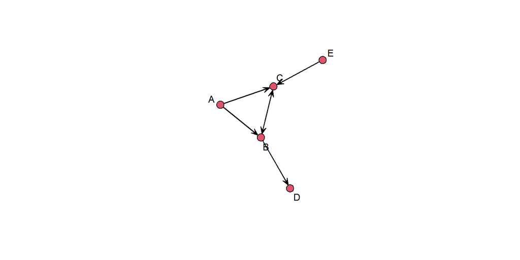

```r
> gplot(mynet, displaylabels=TRUE)
```

## Simple example

- We can add vertex info: color by `sex`

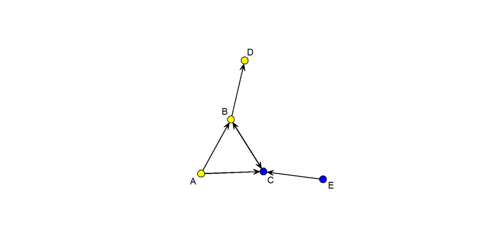

```r
> sex_col = ifelse(v_data$sex == "F","yellow","blue")
> gplot(mynet, displaylabels=TRUE, vertex.col = sex_col)
```

## Simple example using `ggnetwork`

- The package `ggnetwork` can create ggplot type network graphs
- The function `ggnetwork` takes in a network objects and produces plotting coordinates:

```r
> set.seed(1)
> (ggdata=ggnetwork(mynet))
           x         y sex vertex.names      xend       yend
1  0.0000000 0.9749253   M            E 0.4833689 0.94605028
2  0.5083244 0.9445595   M            C 0.8067595 0.53960822
4  0.8215911 0.5194830   F            B 0.5231560 0.92443430
5  0.8215911 0.5194830   F            B 0.7234098 0.02452221
6  1.0000000 1.0000000   F            A 0.8302928 0.54291974
7  1.0000000 1.0000000   F            A 0.5331670 0.94736072
11 1.0000000 1.0000000   F            A 1.0000000 1.00000000
21 0.8215911 0.5194830   F            B 0.8215911 0.51948301
3  0.5083244 0.9445595   M            C 0.5083244 0.94455952
41 0.7185455 0.0000000   F            D 0.7185455 0.00000000
51 0.0000000 0.9749253   M            E 0.0000000 0.97492527
```

## Simple example using `ggnetwork`

- Plot with x/y generated coordinates

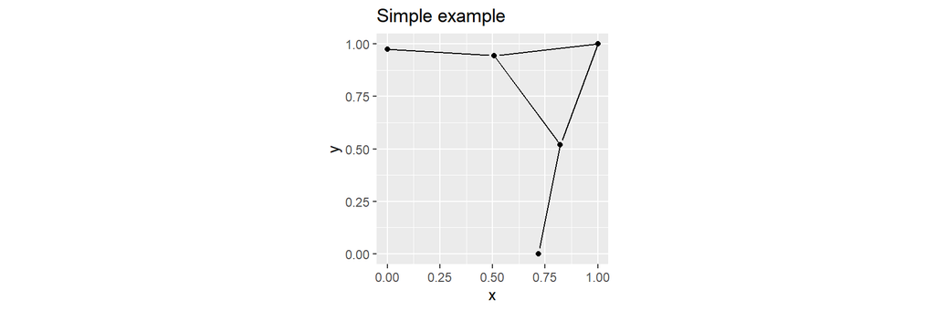

```r
> ggplot(ggdata, aes(x = x, y = y, xend = xend, yend = yend)) +
+   geom_edges() +  geom_nodes() + coord_fixed() + ggtitle("Simple example")
```

## Simple example using `ggnetwork`

- Add directional arrows, node labels and `sex` coloring

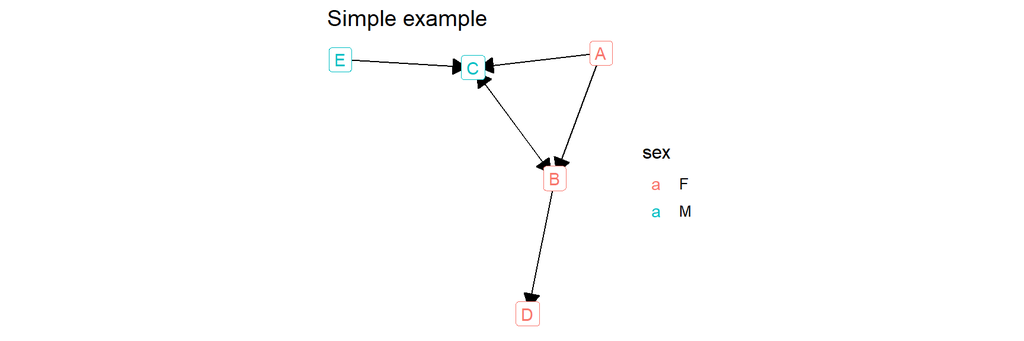

```r
> ggplot(ggdata, aes(x = x, y = y, xend = xend, yend = yend)) +
+   geom_edges(arrow=arrow(length=unit(10,"pt"), type="closed")) + geom_nodes() +
+   theme_blank() + # turns off arbitrary x/y coordinate choices
+   geom_nodelabel(aes(label=vertex.names, color=sex)) +  # sex is a node variable
+   coord_fixed() + ggtitle("Simple example")
```

## Facebook example

- The `network` object was saved as a `RDS` object (single R object)
- Can read it in with `readRDS`: (note it is undirected)

```r
> facebook <- readRDS(gzcon(url("https://raw.githubusercontent.com/mgelman/data/master/facebook")))
> facebook
 Network attributes:
  vertices = 93
  directed = FALSE
  hyper = FALSE
  loops = FALSE
  multiple = FALSE
  bipartite = FALSE
  total edges= 323
    missing edges= 0
    non-missing edges= 323

 Vertex attribute names:
    friend_count group mutual_friend_count NewLabel relationship_status sex vertex.names

No edge attributes
```

## Facebook example

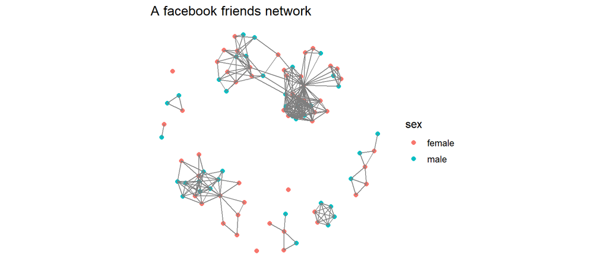

```r
> ggplot(data=ggnetwork(facebook), aes(x = x, y = y, xend = xend, yend = yend)) +
+   geom_nodes(aes(color=sex), size=2) +
+   geom_edges(color="gray50") +
+   theme_blank() + coord_fixed() +
+   ggtitle("A facebook friends network")
```

## Graphing Networks

- Graphs of the same network may have different vertex positions depending on random seed
  - the graph is **relational** and *usually* not tied to a coordinate system!
  - show structure, important vertices (“actors”), subgroups, etc
  - can also show node, edge info via color, size, shape, etc
  - usually, edge length is arbitrary
- There are many ways to display networks
- `gplot` and `ggnetwork` defaults are both `fruchtermanreingold`
  - example of a **force-directed** graphing algorithm
  - pairs of connected nodes are attracted
  - pairs of unconnected nodes are repulsed
  - built by randomly arranging nodes

## Graphing Networks (simple example)

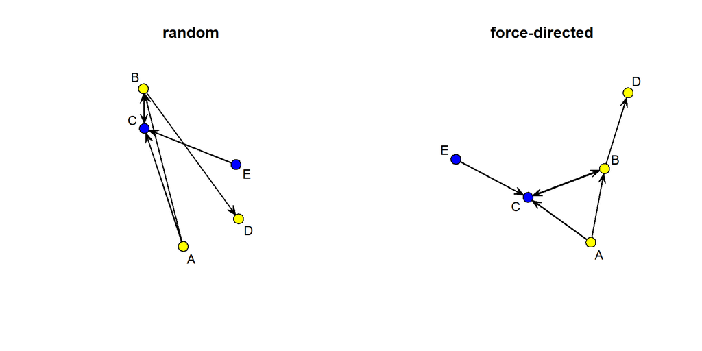

```r
> par(mfrow=c(1,2))
> gplot(mynet, displaylabels=TRUE, vertex.col = sex_col, mode="random", main="random")
> gplot(mynet, displaylabels=TRUE, vertex.col = sex_col, main="force-directed")
```

## Graphing Networks (Facebook)

- see `?gplot.layout` for layout options

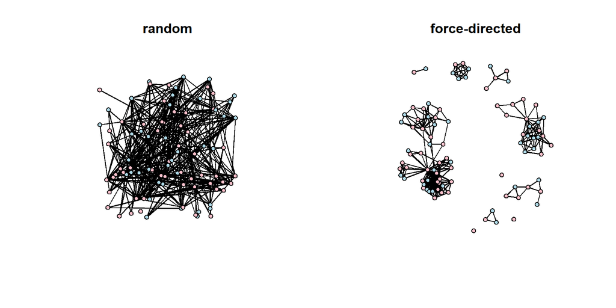

```r
> sex_colface = ifelse((facebook %v% "sex")=="male","lightblue","pink")
> par(mfrow=c(1,2))
> gplot(facebook, gmode="graph", vertex.col = sex_colface, mode="random", main="random")
> gplot(facebook, gmode="graph", vertex.col = sex_colface,  main="force-directed")
```